# Lab 1: R and RStudio

Author

Jonathan Manzano

Published

Due January 31, 2024

## Part A. Introduction to R

Open R (not RStudio). You should see a window that looks something like this (your version number may differ slightly):

[figure not shown]

At the bottom of this window, you should see a `>` symbol. This is called a prompt and indicates that R is waiting for instructions (in the form of code). Type `100 + 100` and then press return or enter. R should produce the following output: `[1] 200`. For now, ignore the `[1]`. This is R’s way of letting us know that the answer is a **single** value: 200.

### 1. Compute $2^{1023}$ by typing the line: `2 ^ 1023`. What is the resulting value? Do you trust R’s answer?

```r
2 ^ 1023
```

```
[1] 8.988466e+307
```

> **I trust R’s answer because I double checked it with a physical calculator, and it calculated the same answer.**

### 2. Compute $2^{1024}$ by typing the line: `2 ^ 1024`. What is the resulting value? Do you trust R’s answer?

```r
2 ^ 1024
```

```
[1] Inf
```

> **I do not trust R’s answer for question two. It states that $2^{1024}$ it is `Inf`. According to WolframAlpha:**

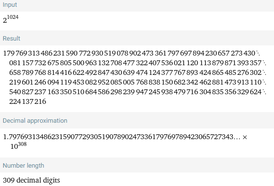

We can save values as objects by giving them names. Try this out by typing `x <- 10` and then pressing return/enter.

```r
x <- 10
```

### 3. What does the command `print(x)` produce? Try to predict what the answer will be before you run the code.

> **I predict that it will print the integer value $10$.**

```r
print(x)
```

```
[1] 10
```

### 4. What does the command `x + 10` produce? Try to predict what the answer will be before you run the code.

> **I predict that it will print the value $20$. Since we implicitly assigned the variable $x$ with the integer $10$, prompting the instruction `x + 10` will result in the console printing the integer $20$.**

```r
x + 10
```

```
[1] 20
```

### 5. Run the following two lines of code, one after the other. What is the result? Try to predict what the answer will be before you run the code.

> **I predict that the console will print the integer value $121$. The first line updates the existing variable $x$ by assigning it the value of its current value, $10$, plus the integer $1$ to the integer $11$ The second line is another way to write $x^{2}$. After the second line executes, $11 \times 11$, the console should print the integer value $121$.**

```r
x <- x + 1
x * x
```

```
[1] 121
```

### 6. Run the following lines of code, one after the other. What is the result? In your own words, explain what this code is doing.

```r
sides <- c("H", "T")
flip1 <- sample(sides, 1, replace = T)
print(flip1)
```

```
[1] "H"
```

> **This simulates a coin tossing experiment with replacement. The coin is flipped once and the side facing up is printed on the console.**

### 7. Run the following lines of code, one after the other. What is the result? In your own words, explain what this code is doing.

```r
sides <- c("H", "T")
flip10 <- sample(sides, 10, replace = T)
print(flip10)
```

```
 [1] "H" "T" "H" "T" "T" "T" "T" "H" "T" "T"
```

> **This simulates a coin tossing experiment with replacement. The coin is flipped $10$ times and, on each flip, the side facing up is printed on the console.**